# Story Board Visualization

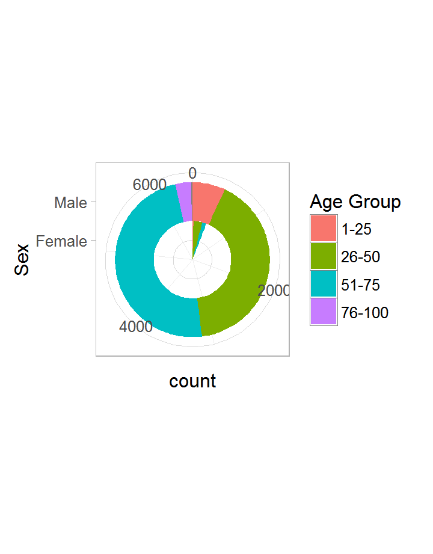

[figure not shown]

[figure not shown]

[figure not shown]

[figure not shown]

[figure not shown]

# Analysis

### The dataset contains a larger proportion of male inmates as compared to female inmates

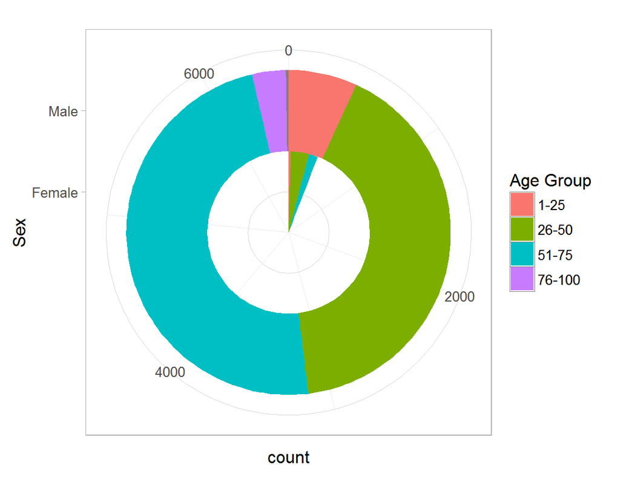

Another observation we can make is that the male inmate distribution represents a wider range of age groups as compared to the female inmates which have a higher concentration in the 26-50 age range, followed by 51-75.

### The Age at the time of death across ethnicities shows considerable variation, especially for the male population

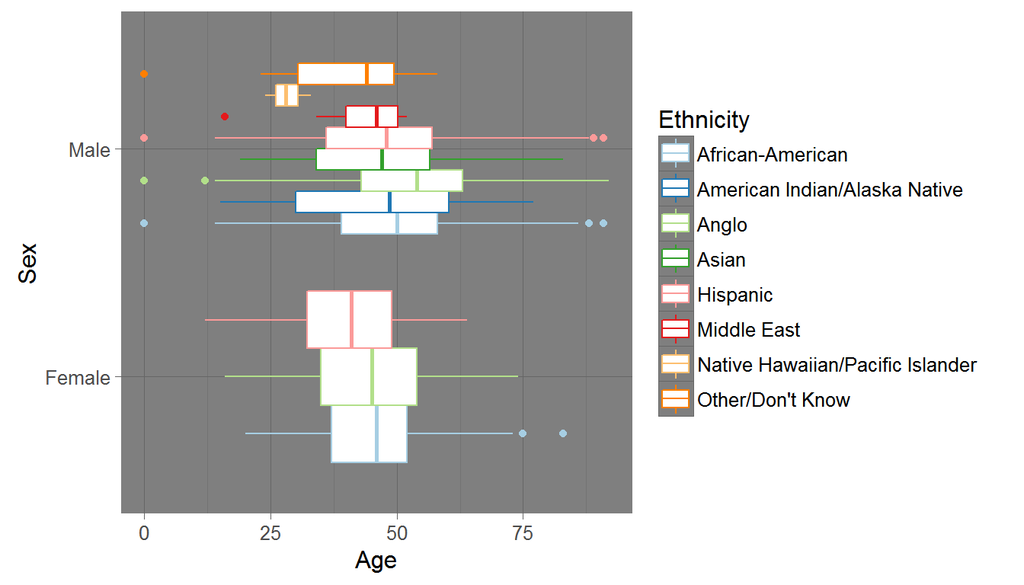

- Another detail we can notice is that there are a few cases in which the age at the time of death was not recorded, specifically in the cases of **African-American**, **Anglo** and **Hispanic**. There is also one case in the category of unknown ethnicity.
- Another interesting observation that sticks out is that the inmates of **Native Hawaiian/Pacific Islander** ethnicity shows a small group of 26-50 year olds who have passed away over the years.
- We can also observe that in the case of female inmates, the only ethnicities observed were **African-American**, **Anglo** and **Hispanic**.

### The manner of death of inmates who were **Male** shows considerable variation and a number of outlier cases. For **Female** inmates, there are fewer outlier cases.

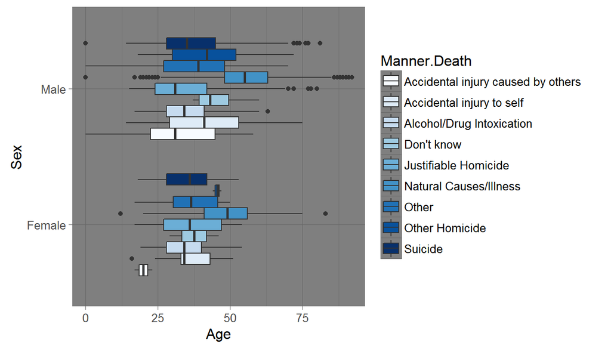

- Another observation that can be made is that there are fewer cases of **Female** inmates who died due to **Accidental Injury cause by Others**, whose age were less than 25 years.
- Additionally, there are very few cases of **Female** inmates whose cause of death were classified as **Other Homicide**, who were in their early to mid 40’s.
- Another observation we can make is that there are significant number of outliers in the case of **Male** inmates whose cause of death was classififed as **Natural Causes/Illness**, followed by those whose death was calssified as **Suicide**.

### On a yearly basis, one can observe that **Penitantiaries** and **County Jails** account for most of the deaths classified as **Natural Causes/Illness**

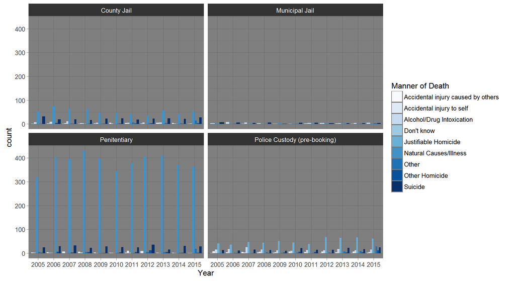

- Most of the deaths that contribute to those classified as **Suicide** also took place mostly at **Penitentiaries** and **County Jails**.
- Another aspect we can observe is that the number of deaths in **Police Custody** that are classified as **Justfiable Homicide** are quite high, even when compared to other institutions.
- Again, we see that **Muncipal Jails** account for a few deaths comparatively.

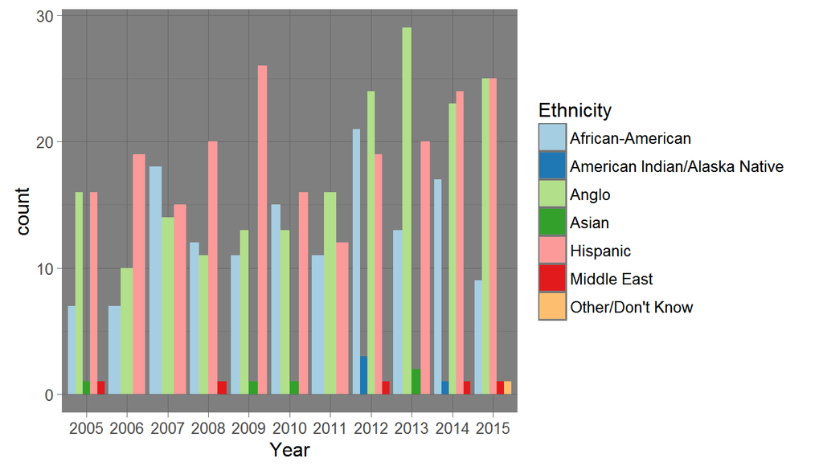

- We can also see that initially, such deaths would happen more often to inmates of **Hispanic** ethnicity but later years saw more of a blance between **Anglo** and **Hispanic** ethnicities.
- It is interesting to see that the inmates whose ethnicity was classified as **Other/Don’t Know** have dates of death only in the year 2015.
- Another observation that can be made is that the number of deaths of **Anglo** ethnicity inmates, whose death was classified as **Justifiable Homicide**, seems to have spiked to the highest amount in 2013 (which is the most number of such deaths across ethnicities).

### Generally, deaths in **Police Custody** which are classified as **Justifiable Homicide** tends to happen to inmates in an age range of 20-40 across ethnicities

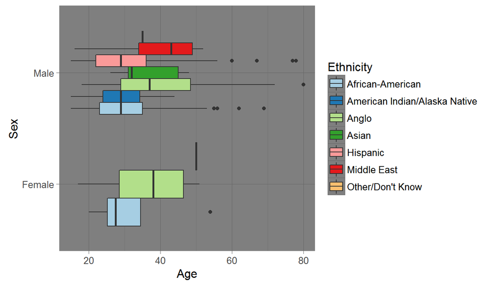

- Another observation that can be made is that there a number of outliers in the case of **Male** inmates of **African-American** and **Hispanic** descent who have died in this way, whose age was above 50.
- There were also comparatiely less **Female** inmates of **Hispanic** descent who died this way (Usually of 50 years of age approximately), and also comparatively less **Male** inmates whose ethnicity was unknown.

### The Department where such deaths occured the most is the **Houston Police Department** with **97** of such occurences

[interactive chart not shown]

- There are two departments with the same amount of such occurences, namely **Dallas Police Department** and **San Antonio Police Department** with **61** of such occurences.
- While not shown here, there are approximately 117 more departments where such occurences have taken place over the years, but these are usually of the order of 1 to 3.

# Details

### Team Members:

- Ashish Syal
- Dean D’souza
- SoujanyaPrakash Bulagannawar